# Linear regression

Raj Kanungo

## Load car for the VIF functionality

```r
if (!require(car)) {
    install.packages("car")
    require(car)
}
```

```r
if (!require(ggplot2)) {
    install.packages("ggplot2")
    require(ggplot2)
}
```

# Load this for visualizing correlations

```r
if (!require(GGally)) {
    install.packages("GGally")
    require(GGally)
}
```

## Load MASS for stepwise regression

```r
if (!require(MASS)) {
    install.packages("MASS")
    require(MASS)
}
```

## Load olsrr for stepwise regression

```r
if (!require(olsrr)) {
    install.packages("olsrr")
    require(olsrr)
}
```

## Read data for regression

We will use a data set from this [site](http://lib.stat.cmu.edu/datasets/). The specific dataset that we will use is wages from the current population survey (CPS) in 1985. Here is the [link](http://lib.stat.cmu.edu/datasets/CPS_85_Wages).

- Make sure data file is in the same folder as this document
- NOte that we provide the requisite column names

```r
mydf <- read.csv("cps.txt", header = FALSE, sep = "\t")
cnames <- c("EDUCATION", "SOUTH", "SEX", "EXPERIENCE", "UNION", "WAGE", "AGE", "RACE", "OCCUPATION", "SECTOR", "MARR")
colnames(mydf) <- cnames
head(mydf)
```

```
##   EDUCATION SOUTH SEX EXPERIENCE UNION  WAGE AGE RACE OCCUPATION SECTOR
## 1         8     0   1         21     0  5.10  35    2          6      1
## 2         9     0   1         42     0  4.95  57    3          6      1
## 3        12     0   0          1     0  6.67  19    3          6      1
## 4        12     0   0          4     0  4.00  22    3          6      0
## 5        12     0   0         17     0  7.50  35    3          6      0
## 6        13     0   0          9     1 13.07  28    3          6      0
##   MARR
## 1    1
## 2    1
## 3    0
## 4    0
## 5    1
## 6    0
```

## Create a smaller subset of data for our regression model

- We will choose to predict WAGE
- The predictors will be EXPERIENCE and EDUCATION

```r
mynewdf <- subset(mydf, select=c(WAGE, EDUCATION, EXPERIENCE))
head(mynewdf)
```

```
##    WAGE EDUCATION EXPERIENCE
## 1  5.10         8         21
## 2  4.95         9         42
## 3  6.67        12          1
## 4  4.00        12          4
## 5  7.50        12         17
## 6 13.07        13          9
```

## Linear regression basics

We start by setting up the model and estimating it. This assumes that the data are clean and and that there are no other issues with the data.

```r
regModel <- lm(WAGE ~ EDUCATION + EXPERIENCE, data = mynewdf)
```

## Summary of regression model

- What are residuals
- Make sure you understand the section on coefficients and how to interpret them
- How do we interpret the stars?
- What is residual standard error?
- What is the difference between R<sup>2</sup> and Adjusted-R<sup>2</sup>?
- What does the p-value at the end tell us?

```r
summary(regModel)
```

```
##
## Call:
## lm(formula = WAGE ~ EDUCATION + EXPERIENCE, data = mynewdf)
##
## Residuals:
##    Min     1Q Median     3Q    Max
## -8.351 -2.857 -0.599  1.994 36.336
##
## Coefficients:
##             Estimate Std. Error t value Pr(>|t|)
## (Intercept)  -4.9045     1.2189  -4.024 6.56e-05 ***
## EDUCATION     0.9260     0.0814  11.375  < 2e-16 ***
## EXPERIENCE    0.1051     0.0172   6.113 1.89e-09 ***
## ---
## Signif. codes:  0 '***' 0.001 '**' 0.01 '*' 0.05 '.' 0.1 ' ' 1
##
## Residual standard error: 4.599 on 531 degrees of freedom
## Multiple R-squared:  0.202,  Adjusted R-squared:  0.199
## F-statistic: 67.22 on 2 and 531 DF,  p-value: < 2.2e-16
```

## Regression diagnostics

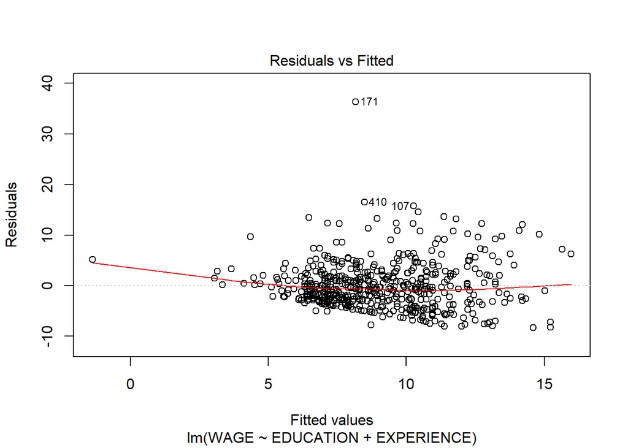

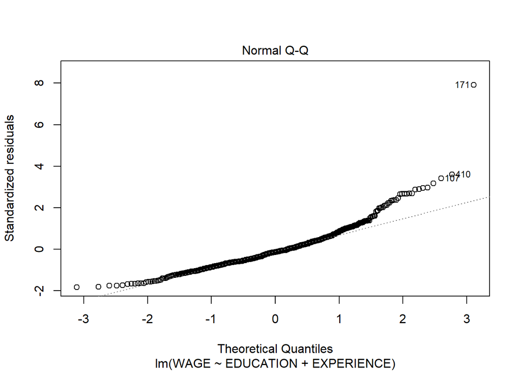

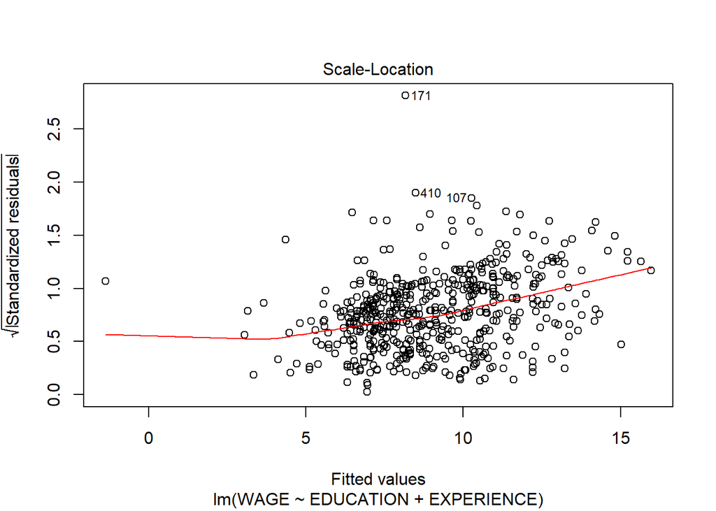

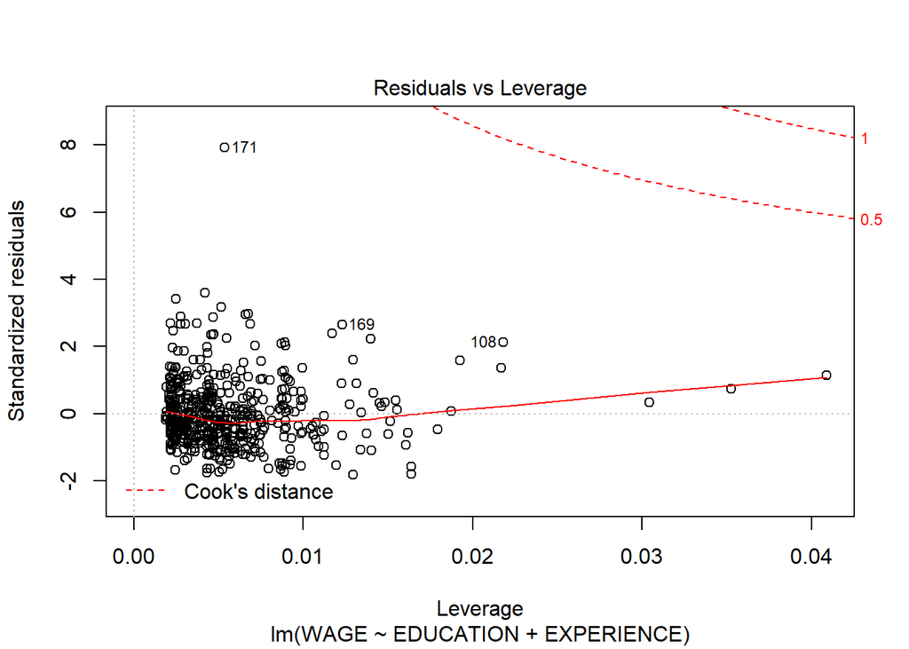

```r
plot(regModel)
```

- Plot #1: (residuals vs. fitted values) is a scatterplot between residuals and predicted values. It should look more or less random. This is more or less what what we see here, with the exception of a single outlier in the top center.
- Plot #2: The second plot (normal Q-Q) is a normal probability plot. It should give a straight line if the errors are distributed normally, but point 171 and a few others force it to deviate from the straight line.
- Plot #3: The third plot (Scale-Location), similar to the the first lot, should look random. No patterns. Ours hasan upward slope.
- Plot #4: The last plot (Cook’s distance) tells us which points have the greatest influence on the regression (leverage points). We see that points 171, 169, and 108 have a lot of influence on the model.

## Let’s get rid of one point and see what happens

We will get rid of point 171

```r
mynewdf <- mynewdf[-(171), ]
```

## Estimate and see summary

Be sure to compare the R<sup>2</sup> values. What is the increase in percentage terms?

```r
regModel <- lm(WAGE ~ EDUCATION + EXPERIENCE, data = mynewdf)
summary(regModel)
```

```
##
## Call:
## lm(formula = WAGE ~ EDUCATION + EXPERIENCE, data = mynewdf)
##
## Residuals:
##     Min      1Q  Median      3Q     Max
## -8.3697 -2.8109 -0.5216  2.0434 16.6930
##
## Coefficients:
##             Estimate Std. Error t value Pr(>|t|)
## (Intercept) -5.15164    1.14609  -4.495 8.55e-06 ***
## EDUCATION    0.92908    0.07652  12.142  < 2e-16 ***
## EXPERIENCE   0.11289    0.01619   6.972 9.32e-12 ***
## ---
## Signif. codes:  0 '***' 0.001 '**' 0.01 '*' 0.05 '.' 0.1 ' ' 1
##
## Residual standard error: 4.323 on 530 degrees of freedom
## Multiple R-squared:  0.2271, Adjusted R-squared:  0.2242
## F-statistic: 77.86 on 2 and 530 DF,  p-value: < 2.2e-16
```

## By the way, how is WAGE distributed?

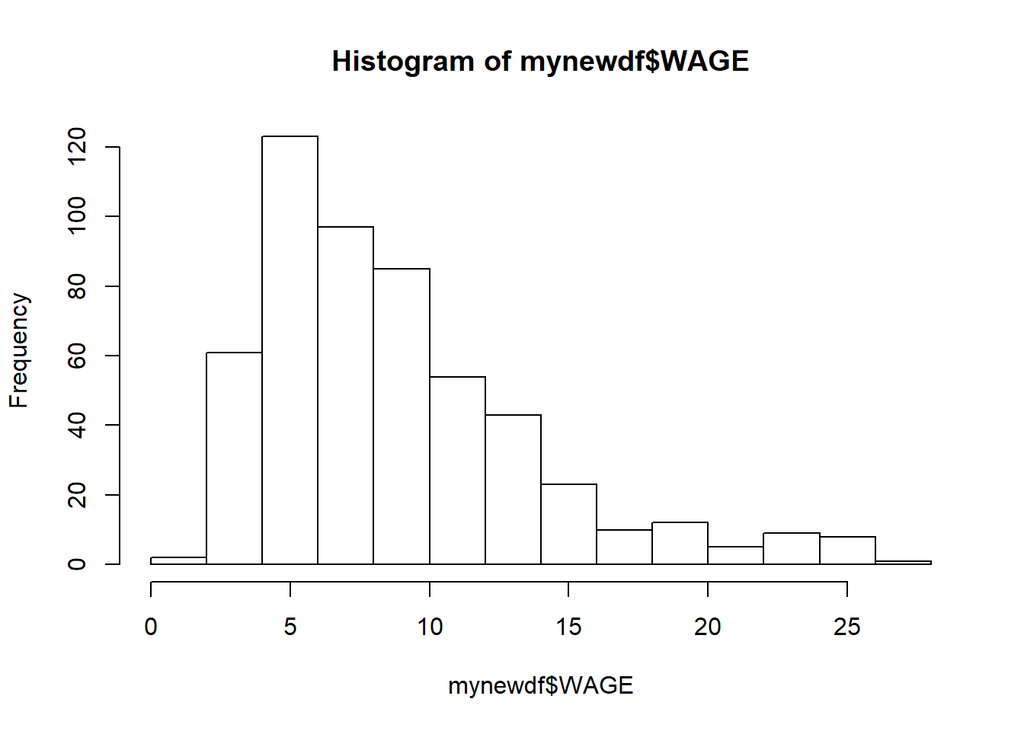

```r
hist(mynewdf$WAGE)
```

## Let’s plot the histogram for the log transform of WAGE

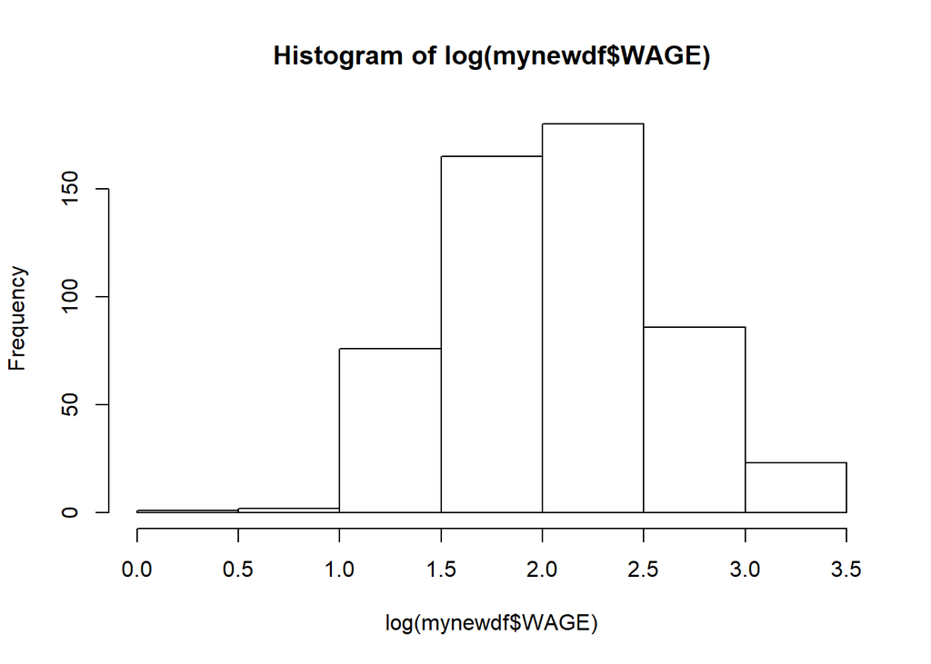

```r
hist(log(mynewdf$WAGE))
```

## It makes sense to use the log transform as the dependent variable

Looks like it does not buy us much

```r
regModel <- lm(log(WAGE) ~ EDUCATION + EXPERIENCE, data = mynewdf)
summary(regModel)
```

```
##
## Call:
## lm(formula = log(WAGE) ~ EDUCATION + EXPERIENCE, data = mynewdf)
##
## Residuals:
##      Min       1Q   Median       3Q      Max
## -2.03251 -0.32422  0.04311  0.32006  1.23656
##
## Coefficients:
##             Estimate Std. Error t value Pr(>|t|)
## (Intercept) 0.581654   0.122762   4.738 2.77e-06 ***
## EDUCATION   0.096571   0.008196  11.783  < 2e-16 ***
## EXPERIENCE  0.012167   0.001734   7.015 7.03e-12 ***
## ---
## Signif. codes:  0 '***' 0.001 '**' 0.01 '*' 0.05 '.' 0.1 ' ' 1
##
## Residual standard error: 0.4631 on 530 degrees of freedom
## Multiple R-squared:  0.2185, Adjusted R-squared:  0.2156
## F-statistic:  74.1 on 2 and 530 DF,  p-value: < 2.2e-16
```

## Evaluate the regression diagnostics

Pay particular attention to Plot #2

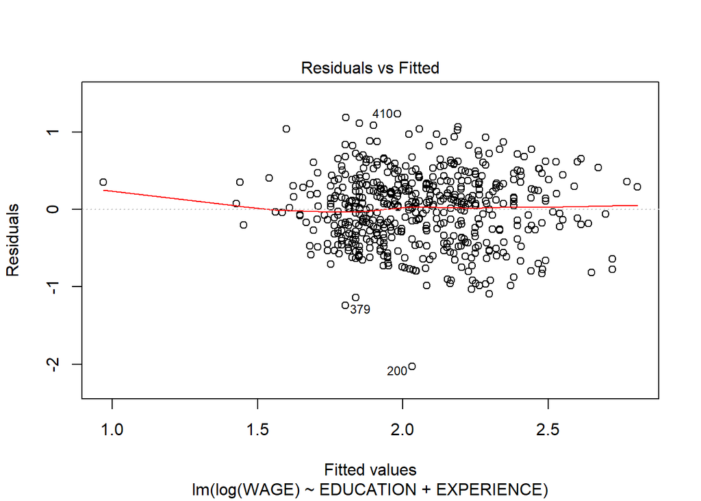

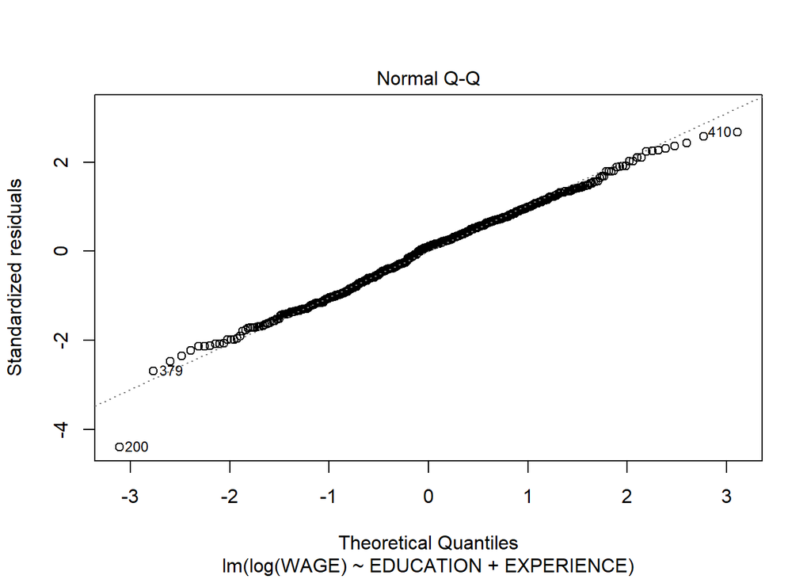

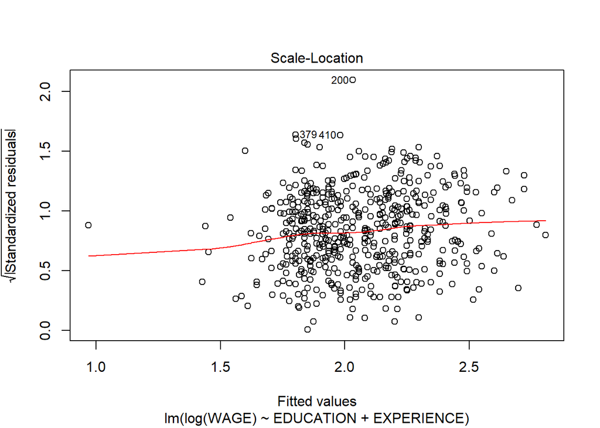

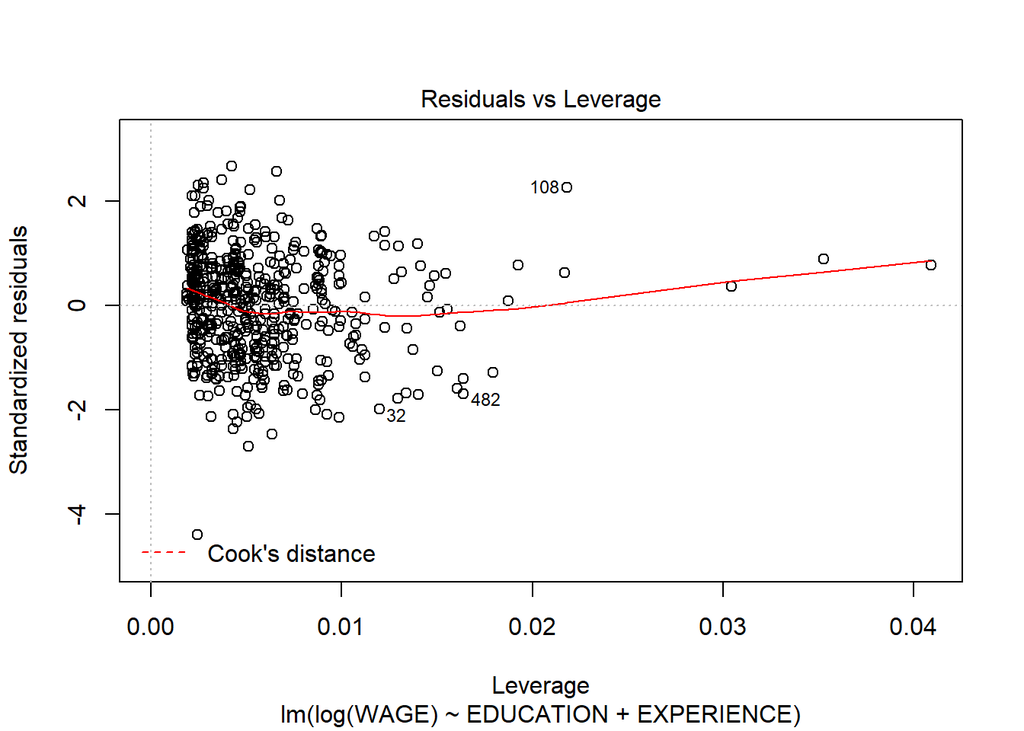

```r
plot(regModel)
```